# Hypothesis Testing Project

Benard Omido

2024-03-07

## Objective

The Objective of this project is to determine whether more goals are scored in women’s international matches than men’s using FIFA data sets.

```r
library(tidyverse)
library(gridExtra)
```

Import the datasets

```r
men_df <- read_csv("men_results.csv")
glimpse(men_df)
```

```
## Rows: 44,353
## Columns: 7
## $ ...1       <dbl> 0, 1, 2, 3, 4, 5, 6, 7, 8, 9, 10, 11, 12, 13, 14, 15, 16, 1~
## $ date       <date> 1872-11-30, 1873-03-08, 1874-03-07, 1875-03-06, 1876-03-04~
## $ home_team  <chr> "Scotland", "England", "Scotland", "England", "Scotland", "~
## $ away_team  <chr> "England", "Scotland", "England", "Scotland", "England", "W~
## $ home_score <dbl> 0, 4, 2, 2, 3, 4, 1, 0, 7, 9, 2, 5, 0, 5, 2, 5, 0, 1, 1, 0,~
## $ away_score <dbl> 0, 2, 1, 2, 0, 0, 3, 2, 2, 0, 1, 4, 3, 4, 3, 1, 1, 6, 5, 13~
## $ tournament <chr> "Friendly", "Friendly", "Friendly", "Friendly", "Friendly",~
```

```r
women_df <- read_csv("women_results.csv")
glimpse(women_df)
```

```
## Rows: 4,884
## Columns: 7
## $ ...1       <dbl> 0, 1, 2, 3, 4, 5, 6, 7, 8, 9, 10, 11, 12, 13, 14, 15, 16, 1~
## $ date       <date> 1969-11-01, 1969-11-01, 1969-11-02, 1969-11-02, 1975-08-25~
## $ home_team  <chr> "Italy", "Denmark", "England", "Italy", "Thailand", "Hong K~
## $ away_team  <chr> "France", "England", "France", "Denmark", "Australia", "New~
## $ home_score <dbl> 1, 4, 2, 3, 3, 0, 3, 3, 3, 0, 3, 3, 5, 3, 5, 2, 1, 5, 7, 1,~
## $ away_score <dbl> 0, 3, 0, 1, 2, 2, 0, 0, 0, 2, 2, 0, 0, 1, 0, 0, 0, 0, 0, 0,~
## $ tournament <chr> "Euro", "Euro", "Euro", "Euro", "AFC Championship", "AFC Ch~
```

Filter the data sets to only include FIFA World Cup Matches since 2002-01-01

```r
men <- men_df %>%
  filter(tournament == "FIFA World Cup", date > "2002-01-01") %>%
  mutate(total_goals = home_score + away_score)

head(men)
```

```
## # A tibble: 6 x 8
##    ...1 date       home_team          away_team home_score away_score tournament
##   <dbl> <date>     <chr>              <chr>          <dbl>      <dbl> <chr>
## 1 25164 2002-05-31 France             Senegal            0          1 FIFA Worl~
## 2 25165 2002-06-01 Germany            Saudi Ar~          8          0 FIFA Worl~
## 3 25166 2002-06-01 Republic of Irela~ Cameroon           1          1 FIFA Worl~
## 4 25167 2002-06-01 Uruguay            Denmark            1          2 FIFA Worl~
## 5 25168 2002-06-02 Argentina          Nigeria            1          0 FIFA Worl~
## 6 25169 2002-06-02 England            Sweden             1          1 FIFA Worl~
## # i 1 more variable: total_goals <dbl>
```

```r
women <- women_df %>%
  filter(tournament == "FIFA World Cup", date > "2002-01-01") %>%
  mutate(total_goals = home_score + away_score)

head(women)
```

```
## # A tibble: 6 x 8
##    ...1 date       home_team     away_team   home_score away_score tournament
##   <dbl> <date>     <chr>         <chr>            <dbl>      <dbl> <chr>
## 1  1600 2003-09-20 Nigeria       North Korea          0          3 FIFA World C~
## 2  1601 2003-09-20 Norway        France               2          0 FIFA World C~
## 3  1602 2003-09-20 Germany       Canada               4          1 FIFA World C~
## 4  1603 2003-09-20 Japan         Argentina            6          0 FIFA World C~
## 5  1604 2003-09-21 United States Sweden               3          1 FIFA World C~
## 6  1605 2003-09-21 Brazil        South Korea          3          0 FIFA World C~
## # i 1 more variable: total_goals <dbl>
```

#### *Research Question*

**Hypothesis**

HO - The mean number of goals scored in women’s international soccer matches is the same as men’s

Checking Normality

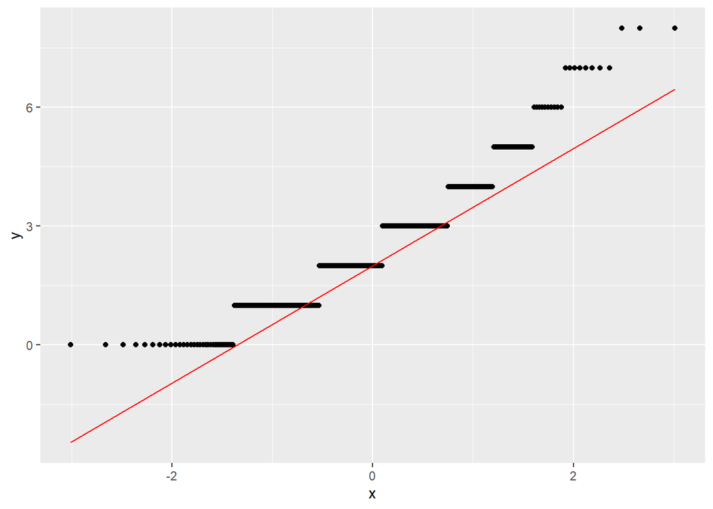

```r
#Using a histogram with a density line
#For men

mens_plot <- ggplot(men, aes(total_goals)) +
  geom_histogram(aes(y = ..density..), bins = 30) +
  stat_function(fun = dnorm, color = "blue",
                args = list(mean = mean(men$total_goals),
                            sd = sd(men$total_goals))) +
  ggtitle("Goals Scored (Mens)") +
  xlab("Goals Scored") +
  ylab("Frequency")

#Alternatively we can use QQ plots

ggplot(men, aes(sample = total_goals)) +
  stat_qq() +
  geom_qq_line(color = "red")
```

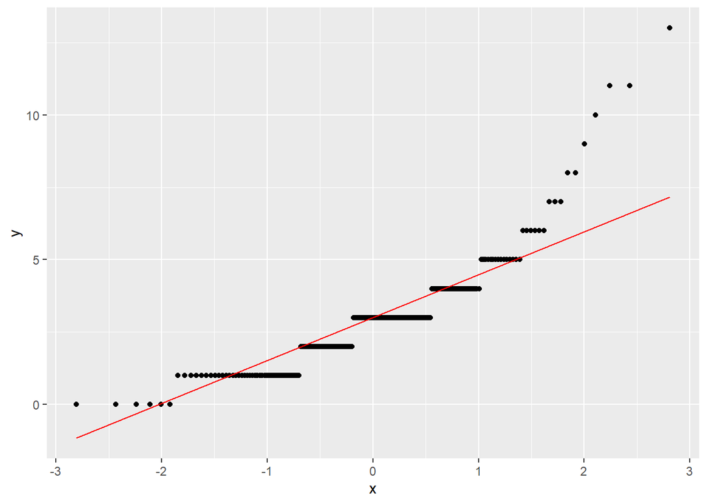

```r
#For women

womens_plot <- ggplot(women, aes(total_goals)) +
  geom_histogram(aes(y = ..density..), bins = 30) +
  stat_function(fun = dnorm, color = "blue",
                args = list(mean = mean(men$total_goals),
                            sd = sd(men$total_goals))) +
  ggtitle("Goals Scored (Womens)") +
  xlab("Goals Scored") +
  ylab("Frequency")

#QQ plot

ggplot(women, aes(sample = total_goals)) +
  stat_qq() +
  geom_qq_line(color = "red")
```

Combine the above histograms for a better comparison using the gridExtra package

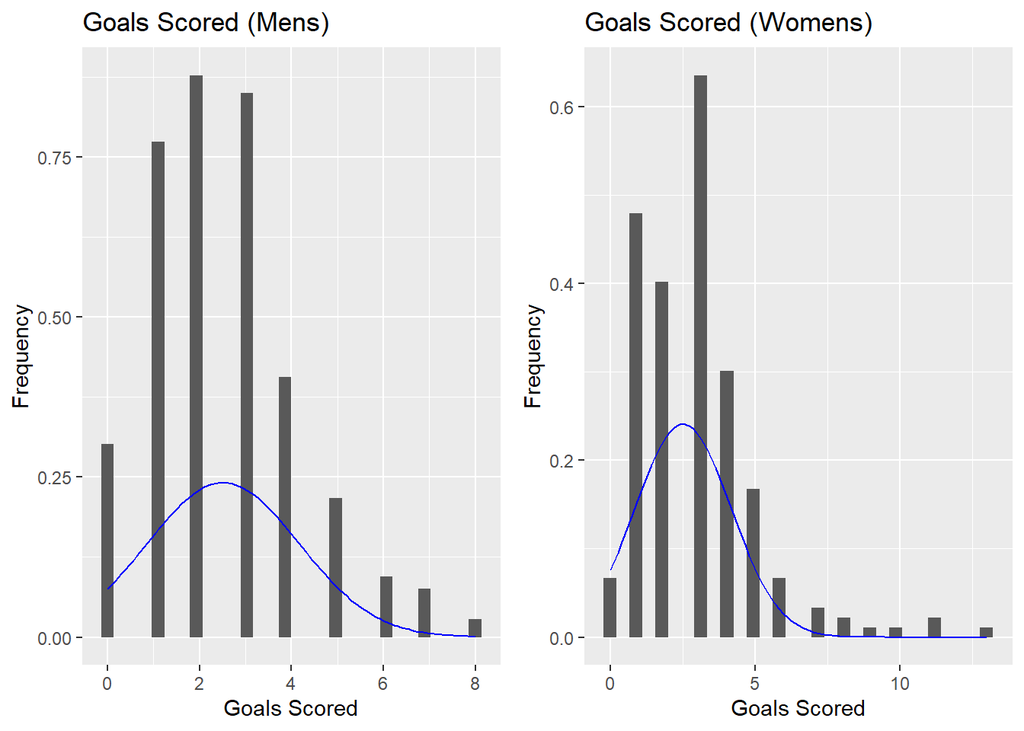

```r
grid.arrange(mens_plot, womens_plot, ncol = 2)
```

The histograms and QQ plots show that both the men’s and women’s data are not normally distributed. We therefore use the Mann Whitney test of two groups, since the normality assumption of a t-test has not being met.

```r
test_results <- wilcox.test(
  x = men$total_goals,
  y = women$total_goals,
  alternative = "greater"
)

test_results
```

```
##
##  Wilcoxon rank sum test with continuity correction
##
## data:  men$total_goals and women$total_goals
## W = 33527, p-value = 0.9949
## alternative hypothesis: true location shift is greater than 0
```

Create a data frame to hold the p-value from above test, and indicate whether we reject or fail to reject the null hypothesis

```r
p_val <- round(test_results$p.value,2)
result <- if_else(p_val < 0.10, "Reject", "Fail to reject")

results_df <- tibble(p_val, result)
results_df
```

```
## # A tibble: 1 x 2
##   p_val result
##   <dbl> <chr>
## 1  0.99 Fail to reject
```